# R Notebook

ZADATAK 4. “Kakav je odnos izmedu BMI-a i krvnog tlaka te možemo li predvidjeti krvni tlak na temelju BMI-a, dobi i učestalosti tjelesne aktivnosti?”

Za početak učitajmo i okvirno pogledajmo podatke, gdje smo na krvni tlak primijenili šum koji smo opisali i obrazložili u prvom zadatku.

```r
library(tidyverse)
# Učitavanje podataka iz csv datoteke:
healthDATA.modif = read.csv("Health Screening Data.csv")

set.seed(906)
healthDATA.modif <- healthDATA.modif %>%
  mutate(
    ap_hi = ap_hi + runif(n(), min = -5, max = 5),
    ap_lo = ap_lo + runif(n(), min = -5, max = 5)
    )

#View(healthDATA.modif)
summary(healthDATA.modif)
```

```
##        X               id             age            gender         height
##  Min.   :    0   Min.   :    0   Min.   :10798   Min.   :1.00   Min.   : 55.0
##  1st Qu.:17497   1st Qu.:25002   1st Qu.:17665   1st Qu.:1.00   1st Qu.:159.0
##  Median :34994   Median :49994   Median :19703   Median :1.00   Median :165.0
##  Mean   :34998   Mean   :49970   Mean   :19469   Mean   :1.35   Mean   :164.4
##  3rd Qu.:52500   3rd Qu.:74890   3rd Qu.:21327   3rd Qu.:2.00   3rd Qu.:170.0
##  Max.   :69999   Max.   :99999   Max.   :23713   Max.   :2.00   Max.   :250.0
##      weight           ap_hi            ap_lo           cholesterol
##  Min.   : 10.00   Min.   :-151.1   Min.   :  -74.56   Min.   :1.000
##  1st Qu.: 65.00   1st Qu.: 116.6   1st Qu.:   76.09   1st Qu.:1.000
##  Median : 72.00   Median : 122.8   Median :   81.02   Median :1.000
##  Mean   : 74.21   Mean   : 126.7   Mean   :   96.64   Mean   :1.367
##  3rd Qu.: 82.00   3rd Qu.: 137.0   3rd Qu.:   87.19   3rd Qu.:2.000
##  Max.   :200.00   Max.   : 244.3   Max.   :10997.51   Max.   :3.000
##       gluc           smoke              alco             active
##  Min.   :1.000   Min.   :0.00000   Min.   :0.00000   Min.   :0.0000
##  1st Qu.:1.000   1st Qu.:0.00000   1st Qu.:0.00000   1st Qu.:1.0000
##  Median :1.000   Median :0.00000   Median :0.00000   Median :1.0000
##  Mean   :1.226   Mean   :0.08818   Mean   :0.05377   Mean   :0.8037
##  3rd Qu.:1.000   3rd Qu.:0.00000   3rd Qu.:0.00000   3rd Qu.:1.0000
##  Max.   :3.000   Max.   :1.00000   Max.   :1.00000   Max.   :1.0000
##      cardio          AgeinYr           BMI            BMICat
##  Min.   :0.0000   Min.   :29.00   Min.   :  3.50   Length:69960
##  1st Qu.:0.0000   1st Qu.:48.00   1st Qu.: 23.90   Class :character
##  Median :0.0000   Median :53.00   Median : 26.40   Mode  :character
##  Mean   :0.4996   Mean   :52.84   Mean   : 27.56
##  3rd Qu.:1.0000   3rd Qu.:58.00   3rd Qu.: 30.20
##  Max.   :1.0000   Max.   :64.00   Max.   :298.70
##    AgeGroup
##  Length:69960
##  Class :character
##  Mode  :character
##
##
##
```

Prije nego što krenemo s analizom preko linearne regresije, želimo izbaciti outliere za relevantne veličine. Obratimo pažnju na sistolički krvni tlak “ap_hi”, imamo:
$$IQR = 137 -
116.6 = 20.4$$
Pa dobivamo za donju i gornju granicu:
$$Q_1 - 1.5\cdot IQR = 86$$
$$Q_3 + 1.5 \cdot IQR = 167.6$$
Slično za dijastolički “ap_lo” imamo:
$$IQR = 87.19 -
76.09 = 11.1$$
$$Q_1 - 1.5 \cdot IQR =
59.44$$
$$Q_3 + 1.5 \cdot IQR=
103.84$$
Isti postupak radimo za BMI:
$$IQR = 6.3$$
$$Q_1 - 1.5 \cdot IQR = 14.45$$
$$Q_3 + 1.5 \cdot IQR = 39.65$$
Dob ispitanika nismo odlučili filtrirati jer minimalna i maksimalna dob (29.5835 i 64.9671 godina) zdravorazumski ne predstavljaju “outliere”. Prema ovim rezultatima ćemo filtrirati podatke.

```r
library(tidyverse)

filtered_data <- subset(healthDATA.modif,
                        ap_hi > 86 & ap_hi < 167.6
                        & BMI > 14.45 & BMI < 39.65
                        & ap_lo > 59.44 & ap_lo < 103.84)
summary(filtered_data)
```

```
##        X               id             age            gender
##  Min.   :    0   Min.   :    0   Min.   :10798   Min.   :1.000
##  1st Qu.:17434   1st Qu.:24904   1st Qu.:17649   1st Qu.:1.000
##  Median :34989   Median :49983   Median :19696   Median :1.000
##  Mean   :34988   Mean   :49956   Mean   :19455   Mean   :1.355
##  3rd Qu.:52488   3rd Qu.:74871   3rd Qu.:21316   3rd Qu.:2.000
##  Max.   :69999   Max.   :99999   Max.   :23713   Max.   :2.000
##      height          weight           ap_hi            ap_lo
##  Min.   :120.0   Min.   : 28.00   Min.   : 86.04   Min.   : 59.44
##  1st Qu.:159.0   1st Qu.: 65.00   1st Qu.:116.62   1st Qu.: 76.14
##  Median :165.0   Median : 71.00   Median :122.41   Median : 80.74
##  Mean   :164.6   Mean   : 73.03   Mean   :125.49   Mean   : 81.03
##  3rd Qu.:170.0   3rd Qu.: 80.00   3rd Qu.:134.80   3rd Qu.: 85.69
##  Max.   :207.0   Max.   :135.00   Max.   :167.60   Max.   :103.84
##   cholesterol         gluc           smoke             alco
##  Min.   :1.000   Min.   :1.000   Min.   :0.0000   Min.   :0.00000
##  1st Qu.:1.000   1st Qu.:1.000   1st Qu.:0.0000   1st Qu.:0.00000
##  Median :1.000   Median :1.000   Median :0.0000   Median :0.00000
##  Mean   :1.351   Mean   :1.219   Mean   :0.0881   Mean   :0.05261
##  3rd Qu.:1.000   3rd Qu.:1.000   3rd Qu.:0.0000   3rd Qu.:0.00000
##  Max.   :3.000   Max.   :3.000   Max.   :1.0000   Max.   :1.00000
##      active           cardio          AgeinYr          BMI
##  Min.   :0.0000   Min.   :0.0000   Min.   :29.0   Min.   :14.50
##  1st Qu.:1.0000   1st Qu.:0.0000   1st Qu.:48.0   1st Qu.:23.80
##  Median :1.0000   Median :0.0000   Median :53.0   Median :26.10
##  Mean   :0.8042   Mean   :0.4829   Mean   :52.8   Mean   :26.96
##  3rd Qu.:1.0000   3rd Qu.:1.0000   3rd Qu.:58.0   3rd Qu.:29.70
##  Max.   :1.0000   Max.   :1.0000   Max.   :64.0   Max.   :39.60
##     BMICat            AgeGroup
##  Length:63315       Length:63315
##  Class :character   Class :character
##  Mode  :character   Mode  :character
##
##
##
```

Sada ćemo metodom najmanjih kvadrata pokušati uspostaviti vezu između BMI-a i krvnog tlaka.

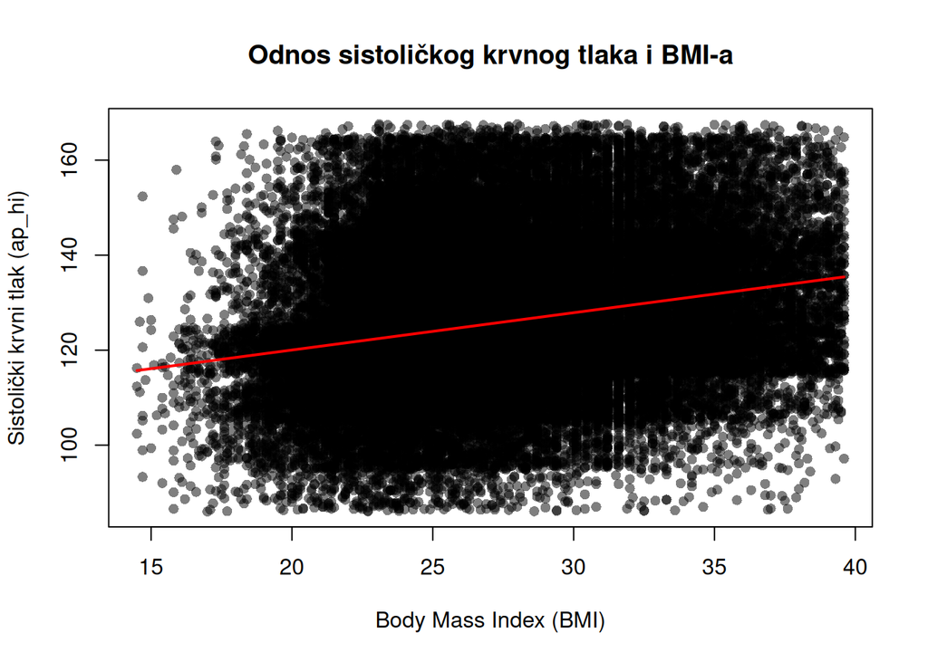

```r
fit.ap_hi <- lm(ap_hi ~ poly(BMI,1) , data = filtered_data)

plot(filtered_data$BMI, filtered_data$ap_hi,
     main = "Odnos sistoličkog krvnog tlaka i BMI-a",
     xlab = "Body Mass Index (BMI)",
     ylab = "Sistolički krvni tlak (ap_hi)",
     pch = 16, col = rgb(0, 0, 0, 0.5))


sorted_index <- order(filtered_data$BMI)
lines(filtered_data$BMI[sorted_index],
      fit.ap_hi$fitted.values[sorted_index],
      col = "red", lwd = 2)
```